# Regression Model for Song Year Prediction Using Python Take 1

### February 22, 2019

Template Credit: Adapted from a template made available by Dr. Jason Brownlee of Machine Learning Mastery. https://machinelearningmastery.com/

SUMMARY: The purpose of this project is to construct prediction model using various machine learning algorithms and to document the end-to-end steps using a template. The Song Year Prediction dataset is a classic regression situation where we are trying to predict the value of a continuous variable.

INTRODUCTION: This data is a subset of the Million Song Dataset, http://labrosa.ee.columbia.edu/millionsong/, a collaboration between LabROSA (Columbia University) and The Echo Nest. The purpose of this exercise is to predict the release year of a song from audio features. Songs are mostly western, commercial tracks ranging from 1922 to 2011, with a peak in the year 2000s. The data preparer recommended the train/test split of first 463,715 examples for training and the last 51,630 examples for testing. This approach avoids the 'producer effect' by making sure no song from a given artist ends up in both the train and test set.

ANALYSIS: The baseline performance of the machine learning algorithms achieved an average RMSE of 10.25. Two algorithms (Ridge Regression and Stochastic Gradient Boosting) achieved the top RMSE metrics after the first round of modeling. After a series of tuning trials, Stochastic Gradient Boosting turned in the top overall result and achieved an RMSE metric of 9.07. By using the optimized parameters, the Stochastic Gradient Boosting algorithm processed the testing dataset with a RMSE of 9.09, which was on-par with the training data.

CONCLUSION: For this iteration, the Stochastic Gradient Boosting algorithm achieved the best overall results using the training and testing datasets. For this dataset, Stochastic Gradient Boosting should be considered for further modeling or production use.

Dataset Used: YearPredictionMSD Data Set

Dataset ML Model: Regression with numerical attributes

Dataset Reference: https://archive.ics.uci.edu/ml/datasets/YearPredictionMSD

Thierry Bertin-Mahieux, Daniel P.W. Ellis, Brian Whitman, and Paul Lamere. The Million Song Dataset. In Proceedings of the 12th International Society for Music Information Retrieval Conference (ISMIR 2011), 2011.

One potential source of performance benchmarks: https://www.kaggle.com/uciml/msd-audio-features/home

The project aims to touch on the following areas:

- Document a predictive modeling problem end-to-end.
- Explore data cleaning and transformation options
- Explore non-ensemble and ensemble algorithms for baseline model performance
- Explore algorithm tuning techniques for improving model performance

Any predictive modeling machine learning project genrally can be broken down into about six major tasks:

1. Prepare Problem
2. Summarize Data
3. Prepare Data
4. Model and Evaluate Algorithms
5. Improve Accuracy or Results
6. Finalize Model and Present Results

## Section 1 - Prepare Problem

### 1.a) Load ibraries

```python
import math
import numpy as np
import pandas as pd
import os
import shutil
import urllib.request
import zipfile
import smtplib
from email.message import EmailMessage
from numpy import arange
from matplotlib import pyplot
from pandas import read_csv
from pandas import get_dummies
from pandas.plotting import scatter_matrix
from sklearn.preprocessing import StandardScaler
from sklearn.model_selection import train_test_split
from sklearn.model_selection import KFold
from sklearn.model_selection import cross_val_score
from sklearn.model_selection import GridSearchCV
from sklearn.metrics import mean_squared_error
from sklearn.pipeline import Pipeline
from sklearn.linear_model import LinearRegression
from sklearn.linear_model import Ridge
from sklearn.linear_model import Lasso
from sklearn.linear_model import ElasticNet
from sklearn.tree import DecisionTreeRegressor
from sklearn.neighbors import KNeighborsRegressor
from sklearn.svm import SVR
from sklearn.ensemble import RandomForestRegressor
from sklearn.ensemble import ExtraTreesRegressor
from sklearn.ensemble import GradientBoostingRegressor
from sklearn.externals.joblib import dump
from sklearn.externals.joblib import load
from sklearn.feature_selection import RFE
from datetime import datetime
from imblearn.over_sampling import SMOTE

# Create one random seed number for reproducible results
seedNum = 888
```

### 1.b) Set up the email notification function

```python
def email_notify(msg_text):
    sender = "luozhi2488@gmail.com"
    receiver = "dave@contactdavidlowe.com"
    with open('../../email_credential.txt') as f:
        password = f.readline()
        f.close()
    msg = EmailMessage()
    msg.set_content(msg_text)
    msg['Subject'] = 'Notification from Python Regression Script'
    msg['From'] = sender
    msg['To'] = receiver
    server = smtplib.SMTP('smtp.gmail.com', 587)
    server.starttls()
    server.login(sender, password)
    server.send_message(msg)
    server.quit()
```

```python
email_notify("Library and Data Loading has begun! "+datetime.now().strftime('%a %B %d, %Y %I:%M:%S %p'))
```

### 1.c) Load dataset

```python
startTimeScript = datetime.now()

dataset_path = 'https://archive.ics.uci.edu/ml/machine-learning-databases/00203/YearPredictionMSD.txt.zip'
dest_file = os.path.basename(dataset_path)
if (os.path.isfile(dest_file) == False) :
    print('Downloading ' + dataset_path + ' as ' + dest_file)
    with urllib.request.urlopen(dataset_path) as in_resp, open(dest_file, 'wb') as out_file:
        shutil.copyfileobj(in_resp, out_file)
    print(dest_file + 'downloaded!')
    print('Unpacking ' + dest_file)
    with zipfile.ZipFile(dest_file, 'r') as zip_ref:
        zip_ref.extractall('.')
    print(dest_file + 'unpacked!')

inputFile = dest_file
attrNames = ['attr' + str(i) for i in range(1,91)]
colNames = ['targetVar'] + attrNames
xy_original_df = read_csv(inputFile, sep=',', names=colNames, index_col=False)
```

```python
# Use variable totCol to hold the number of columns in the dataframe
totCol = len(xy_original_df.columns)

# Set up variable totAttr for the total number of attribute columns
totAttr = totCol-1
```

```python
# targetCol variable indicates the column location of the target/class variable
# If the first column, set targetCol to 1. If the last column, set targetCol to totCol
# If (targetCol <> 1) and (targetCol <> totCol), be aware when slicing up the dataframes for visualization
targetCol = 1

# Standardize the class column to the name of targetVar if required
# xy_original_df = xy_original_df.rename(columns={'MEDV': 'targetVar'})
```

```python
# We create training datasets (xy_train_df, x_train_df, y_train_df) for various visualization and cleaning/transformation operations
# We create testing datasets (x_test_df, y_test_df) for various visualization and cleaning/transformation operations
# Use 70% of the data to train the models and the remaining for testing/validation

if targetCol == totCol:
    x_original_df = xy_original_df.iloc[:,0:totAttr]
    y_original_df = xy_original_df.iloc[:,totAttr]
else:
    x_original_df = xy_original_df.iloc[:,1:totCol]
    y_original_df = xy_original_df.iloc[:,0]

# validation_size = 0.30
# x_train_df, x_test_df, y_train_df, y_test_df = train_test_split(x_original_df, y_original_df, test_size=validation_size, random_state=seedNum)
# xy_train_df = pd.concat([x_train_df, y_train_df], axis=1)

split_point = 463715
xy_train_df = xy_original_df[:split_point]
x_train_df = x_original_df[:split_point]
x_test_df = x_original_df[split_point:]
y_train_df = y_original_df[:split_point]
y_test_df = y_original_df[split_point:]
print("xy_original_df.shape: {} xy_train_df.shape: {}".format(xy_original_df.shape, xy_train_df.shape))
print("x_train_df.shape: {} y_train_df.shape: {}".format(x_train_df.shape, y_train_df.shape))
print("x_test_df.shape: {} y_test_df.shape: {}".format(x_test_df.shape, y_test_df.shape))
```

```
xy_original_df.shape: (515345, 91) xy_train_df.shape: (463715, 91)
x_train_df.shape: (463715, 90) y_train_df.shape: (463715,)
x_test_df.shape: (51630, 90) y_test_df.shape: (51630,)
```

### 1.d) Set up the key parameters to be used in the script

```python
# Set up the number of row and columns for visualization display. dispRow * dispCol should be >= totAttr
dispCol = 3
if totAttr % dispCol == 0 :
    dispRow = totAttr // dispCol
else :
    dispRow = (totAttr // dispCol) + 1

# Set figure width to 16 and height to 12 (4:3 aspect ratio)
fig_size = pyplot.rcParams["figure.figsize"]
fig_size[0] = 16
fig_size[1] = 12
pyplot.rcParams["figure.figsize"] = fig_size
```

```python
email_notify("Library and Data Loading completed! "+datetime.now().strftime('%a %B %d, %Y %I:%M:%S %p'))
```

## Section 2 - Summarize Data

To gain a better understanding of the data that we have on-hand, we will leverage a number of descriptive statistics and data visualization techniques. The plan is to use the results to consider new questions, review assumptions, and validate hypotheses that we can investigate later with specialized models.

```python
email_notify("Data Summarization and Visualization has begun! "+datetime.now().strftime('%a %B %d, %Y %I:%M:%S %p'))
```

### 2.a) Descriptive statistics

#### 2.a.i) Peek at the data itself.

```python
xy_train_df.head(10)
```

|  | targetVar | attr1 | attr2 | attr3 | attr4 | attr5 | attr6 | attr7 | attr8 | attr9 | ... | attr81 | attr82 | attr83 | attr84 | attr85 | attr86 | attr87 | attr88 | attr89 | attr90 |
| --- | --- | --- | --- | --- | --- | --- | --- | --- | --- | --- | --- | --- | --- | --- | --- | --- | --- | --- | --- | --- | --- |
| 0 | 2001 | 49.94357 | 21.47114 | 73.07750 | 8.74861 | -17.40628 | -13.09905 | -25.01202 | -12.23257 | 7.83089 | ... | 13.01620 | -54.40548 | 58.99367 | 15.37344 | 1.11144 | -23.08793 | 68.40795 | -1.82223 | -27.46348 | 2.26327 |
| 1 | 2001 | 48.73215 | 18.42930 | 70.32679 | 12.94636 | -10.32437 | -24.83777 | 8.76630 | -0.92019 | 18.76548 | ... | 5.66812 | -19.68073 | 33.04964 | 42.87836 | -9.90378 | -32.22788 | 70.49388 | 12.04941 | 58.43453 | 26.92061 |
| 2 | 2001 | 50.95714 | 31.85602 | 55.81851 | 13.41693 | -6.57898 | -18.54940 | -3.27872 | -2.35035 | 16.07017 | ... | 3.03800 | 26.05866 | -50.92779 | 10.93792 | -0.07568 | 43.20130 | -115.00698 | -0.05859 | 39.67068 | -0.66345 |
| 3 | 2001 | 48.24750 | -1.89837 | 36.29772 | 2.58776 | 0.97170 | -26.21683 | 5.05097 | -10.34124 | 3.55005 | ... | 34.57337 | -171.70734 | -16.96705 | -46.67617 | -12.51516 | 82.58061 | -72.08993 | 9.90558 | 199.62971 | 18.85382 |
| 4 | 2001 | 50.97020 | 42.20998 | 67.09964 | 8.46791 | -15.85279 | -16.81409 | -12.48207 | -9.37636 | 12.63699 | ... | 9.92661 | -55.95724 | 64.92712 | -17.72522 | -1.49237 | -7.50035 | 51.76631 | 7.88713 | 55.66926 | 28.74903 |
| 5 | 2001 | 50.54767 | 0.31568 | 92.35066 | 22.38696 | -25.51870 | -19.04928 | 20.67345 | -5.19943 | 3.63566 | ... | 6.59753 | -50.69577 | 26.02574 | 18.94430 | -0.33730 | 6.09352 | 35.18381 | 5.00283 | -11.02257 | 0.02263 |
| 6 | 2001 | 50.57546 | 33.17843 | 50.53517 | 11.55217 | -27.24764 | -8.78206 | -12.04282 | -9.53930 | 28.61811 | ... | 11.63681 | 25.44182 | 134.62382 | 21.51982 | 8.17570 | 35.46251 | 11.57736 | 4.50056 | -4.62739 | 1.40192 |
| 7 | 2001 | 48.26892 | 8.97526 | 75.23158 | 24.04945 | -16.02105 | -14.09491 | 8.11871 | -1.87566 | 7.46701 | ... | 18.03989 | -58.46192 | -65.56438 | 46.99856 | -4.09602 | 56.37650 | -18.29975 | -0.30633 | 3.98364 | -3.72556 |
| 8 | 2001 | 49.75468 | 33.99581 | 56.73846 | 2.89581 | -2.92429 | -26.44413 | 1.71392 | -0.55644 | 22.08594 | ... | 18.70812 | 5.20391 | -27.75192 | 17.22100 | -0.85210 | -15.67150 | -26.36257 | 5.48708 | -9.13495 | 6.08680 |
| 9 | 2007 | 45.17809 | 46.34234 | -40.65357 | -2.47909 | 1.21253 | -0.65302 | -6.95536 | -12.20040 | 17.02512 | ... | -4.36742 | -87.55285 | -70.79677 | 76.57355 | -7.71727 | 3.26926 | -298.49845 | 11.49326 | -89.21804 | -15.09719 |

10 rows × 91 columns

#### 2.a.ii) Dimensions of the dataset.

```python
xy_train_df.shape
```

```
(463715, 91)
```

#### 2.a.iii) Types of the attributes.

```python
xy_train_df.dtypes
```

```
targetVar      int64
attr1        float64
attr2        float64
attr3        float64
attr4        float64
attr5        float64
attr6        float64
attr7        float64
attr8        float64
attr9        float64
attr10       float64
attr11       float64
attr12       float64
attr13       float64
attr14       float64
attr15       float64
attr16       float64
attr17       float64
attr18       float64
attr19       float64
attr20       float64
attr21       float64
attr22       float64
attr23       float64
attr24       float64
attr25       float64
attr26       float64
attr27       float64
attr28       float64
attr29       float64
              ...
attr61       float64
attr62       float64
attr63       float64
attr64       float64
attr65       float64
attr66       float64
attr67       float64
attr68       float64
attr69       float64
attr70       float64
attr71       float64
attr72       float64
attr73       float64
attr74       float64
attr75       float64
attr76       float64
attr77       float64
attr78       float64
attr79       float64
attr80       float64
attr81       float64
attr82       float64
attr83       float64
attr84       float64
attr85       float64
attr86       float64
attr87       float64
attr88       float64
attr89       float64
attr90       float64
Length: 91, dtype: object
```

#### 2.a.iv) Statistical summary of all attributes.

```python
xy_train_df.describe()
```

|  | targetVar | attr1 | attr2 | attr3 | attr4 | attr5 | attr6 | attr7 | attr8 | attr9 | ... | attr81 | attr82 | attr83 | attr84 | attr85 | attr86 | attr87 | attr88 | attr89 | attr90 |
| --- | --- | --- | --- | --- | --- | --- | --- | --- | --- | --- | --- | --- | --- | --- | --- | --- | --- | --- | --- | --- | --- |
| count | 463715.000000 | 463715.000000 | 463715.000000 | 463715.000000 | 463715.000000 | 463715.000000 | 463715.000000 | 463715.000000 | 463715.000000 | 463715.000000 | ... | 463715.000000 | 463715.000000 | 463715.000000 | 463715.000000 | 463715.000000 | 463715.000000 | 463715.000000 | 463715.000000 | 463715.000000 | 463715.000000 |
| mean | 1998.386095 | 43.385488 | 1.261091 | 8.650195 | 1.130763 | -6.512725 | -9.565527 | -2.384609 | -1.793722 | 3.714584 | ... | 15.743361 | -73.067753 | 41.423976 | 37.780868 | 0.345259 | 17.599280 | -26.364826 | 4.444985 | 19.739307 | 1.323326 |
| std | 10.939767 | 6.079139 | 51.613473 | 35.264750 | 16.334672 | 22.855820 | 12.836758 | 14.580245 | 7.961876 | 10.579241 | ... | 32.086356 | 175.376872 | 121.794610 | 94.874474 | 16.153797 | 114.336522 | 174.187892 | 13.320996 | 184.843503 | 22.045404 |
| min | 1922.000000 | 1.749000 | -337.092500 | -301.005060 | -154.183580 | -181.953370 | -81.794290 | -188.214000 | -72.503850 | -126.479040 | ... | -437.722030 | -4402.376440 | -1810.689190 | -3098.350310 | -341.789120 | -3168.924570 | -4319.992320 | -236.039260 | -7458.378150 | -318.223330 |
| 25% | 1994.000000 | 39.957540 | -26.153810 | -11.441920 | -8.515155 | -20.636960 | -18.468705 | -10.776340 | -6.461400 | -2.303600 | ... | -1.798085 | -139.062035 | -20.918635 | -4.711470 | -6.758160 | -31.563615 | -101.396245 | -2.572830 | -59.598030 | -8.813335 |
| 50% | 2002.000000 | 44.262570 | 8.371550 | 10.470520 | -0.691610 | -5.992740 | -11.208850 | -2.047850 | -1.735440 | 3.816840 | ... | 9.161360 | -52.878010 | 28.709870 | 33.494550 | 0.828350 | 15.554490 | -21.123570 | 3.111120 | 7.586950 | 0.052840 |
| 75% | 2006.000000 | 47.833650 | 36.143780 | 29.741165 | 8.756995 | 7.749590 | -2.422590 | 6.515710 | 2.905130 | 9.950960 | ... | 26.248290 | 13.620660 | 89.419995 | 77.674700 | 8.495715 | 67.743725 | 52.299850 | 9.948955 | 86.203115 | 9.670740 |
| max | 2011.000000 | 61.970140 | 384.065730 | 322.851430 | 289.527430 | 262.068870 | 119.815590 | 172.402680 | 105.210280 | 146.297950 | ... | 840.973380 | 4469.454870 | 3210.701700 | 1672.647100 | 260.544900 | 3662.065650 | 2833.608950 | 463.419500 | 7393.398440 | 600.766240 |

8 rows × 91 columns

#### 2.a.v) Count missing values.

```python
print('Number of NaN in the dataframe columns:\n', xy_train_df.isnull().sum())
print('Total number of NaN in the dataframe: ', xy_train_df.isnull().sum().sum())
```

```
Number of NaN in the dataframe columns:
 targetVar    0
attr1        0
attr2        0
attr3        0
attr4        0
attr5        0
attr6        0
attr7        0
attr8        0
attr9        0
attr10       0
attr11       0
attr12       0
attr13       0
attr14       0
attr15       0
attr16       0
attr17       0
attr18       0
attr19       0
attr20       0
attr21       0
attr22       0
attr23       0
attr24       0
attr25       0
attr26       0
attr27       0
attr28       0
attr29       0
            ..
attr61       0
attr62       0
attr63       0
attr64       0
attr65       0
attr66       0
attr67       0
attr68       0
```

[output cut: 9 more lines]

```
attr78       0
attr79       0
attr80       0
attr81       0
attr82       0
attr83       0
attr84       0
attr85       0
attr86       0
attr87       0
attr88       0
attr89       0
attr90       0
Length: 91, dtype: int64
Total number of NaN in the dataframe:  0
```

### 2.b) Data visualizations

##### 2.b.i) Univariate plots to better understand each attribute

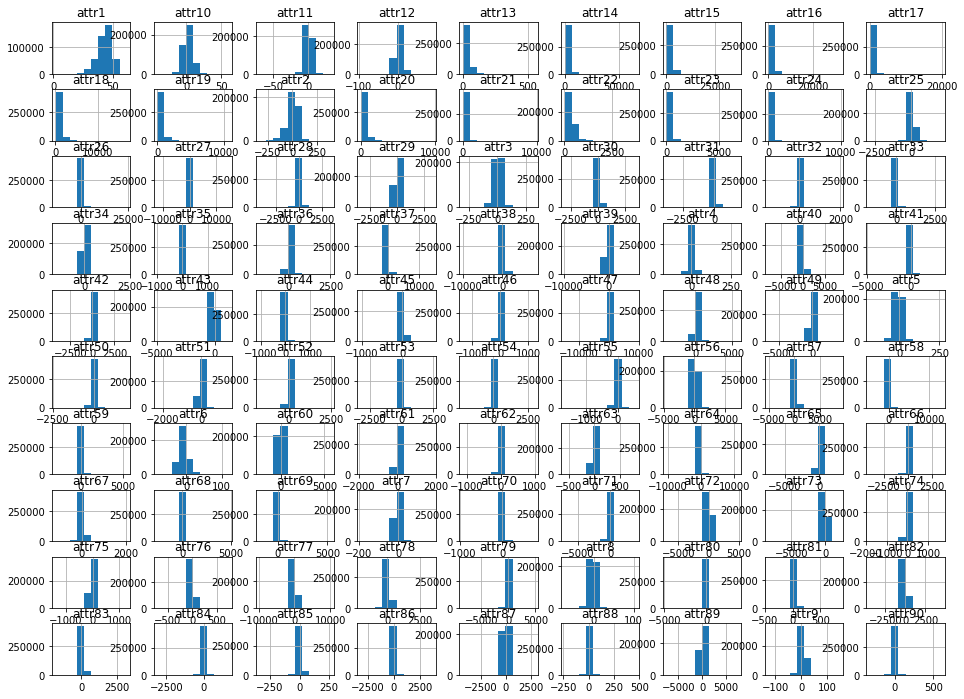

```python
# Histograms for each attribute
x_train_df.hist()
pyplot.show()
```

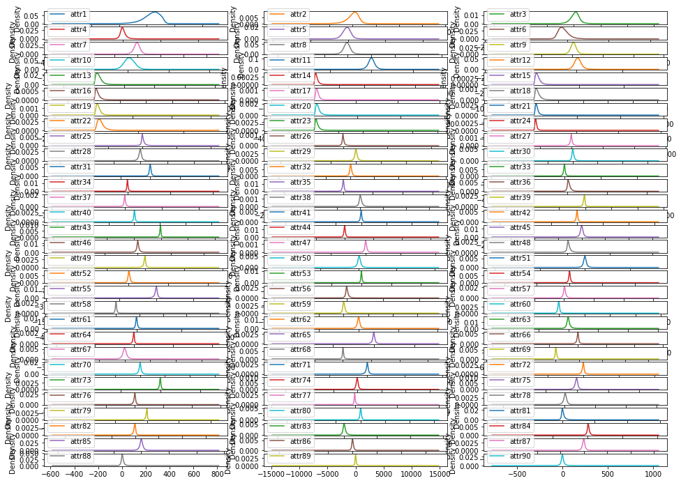

```python
# Density plot for each attribute
x_train_df.plot(kind='density', subplots=True, layout=(dispRow,dispCol), sharex=False, sharey=False)
pyplot.show()
```

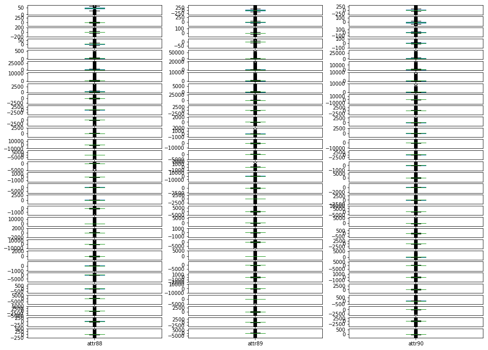

```python
# Box and Whisker plot for each attribute
x_train_df.plot(kind='box', subplots=True, layout=(dispRow,dispCol), sharex=False, sharey=False)
pyplot.show()
```

#### 2.b.ii) Multivariate plots to better understand the relationships between attributes

```python
# Scatterplot matrix
# scatter_matrix(x_train_df)
# pyplot.show()
```

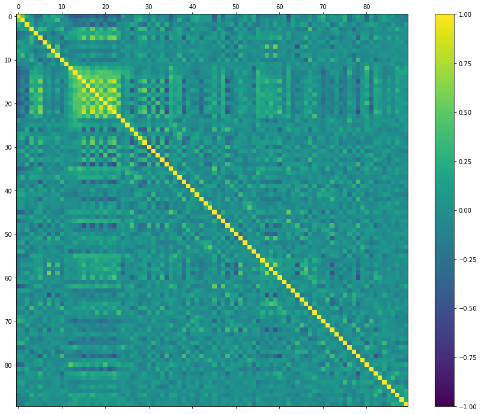

```python
# Correlation matrix
fig = pyplot.figure()
ax = fig.add_subplot(111)
correlations = x_train_df.corr(method='pearson')
cax = ax.matshow(correlations, vmin=-1, vmax=1)
fig.colorbar(cax)
pyplot.show()
```

```python
email_notify("Data Summarization and Visualization completed! "+datetime.now().strftime('%a %B %d, %Y %I:%M:%S %p'))
```

## Section 3 - Prepare Data

Some dataset may require additional preparation activities that will best exposes the structure of the problem and the relationships between the input attributes and the output variable. Some data-prep tasks might include:

- Cleaning data by removing duplicates, marking missing values and even imputing missing values.
- Feature selection where redundant features may be removed.
- Data transforms where attributes are scaled or redistributed in order to best expose the structure of the problem later to learning algorithms.

```python
email_notify("Data Cleaning and Transformation has begun! "+datetime.now().strftime('%a %B %d, %Y %I:%M:%S %p'))
```

### 3.a) Data Cleaning

```python
# Not applicable for this iteration of the project
```

### 3.b) Feature Selection

```python
# Not applicable for this iteration of the project
```

### 3.c) Data Transforms

```python
# Not applicable for this iteration of the project
```

### 3.d) Display the Final Datasets for Model-Building

```python
# We finalize the training and testing datasets for the modeling activities
x_train = x_train_df.values
y_train = y_train_df.values
x_test = x_test_df.values
y_test = y_test_df.values
print("x_train.shape: {} y_train.shape: {}".format(x_train.shape, y_train.shape))
print("x_test.shape: {} y_test.shape: {}".format(x_test.shape, y_test.shape))
email_notify("Data Cleaning and Transformation completed! "+datetime.now().strftime('%a %B %d, %Y %I:%M:%S %p'))
```

```
x_train.shape: (463715, 90) y_train.shape: (463715,)
x_test.shape: (51630, 90) y_test.shape: (51630,)
```

## 4. Model and Evaluate Algorithms

After the data-prep, we next work on finding a workable model by evaluating a subset of machine learning algorithms that are good at exploiting the structure of the training. The typical evaluation tasks include:

- Defining test options such as cross validation and the evaluation metric to use.
- Spot checking a suite of linear and nonlinear machine learning algorithms.
- Comparing the estimated accuracy of algorithms.

For this project, we will evaluate four linear, two non-linear, and three ensemble algorithms:

Linear Algorithms: Linear Regression, Ridge Regression, LASSO Regression, and Elastic Net Regression

Non-Linear Algorithms: Decision Trees (CART) and k-Nearest Neighbors

Ensemble Algorithms: Random Forest, Extra Trees, and Stochastic Gradient Boosting

The random number seed is reset before each run to ensure that the evaluation of each algorithm is performed using the same data splits. It ensures the results are directly comparable.

### 4.a) Set test options and evaluation metric

```python
# Run algorithms using 10-fold cross validation
num_folds = 10
scoring = 'neg_mean_squared_error'
```

```python
# Set up Algorithms Spot-Checking Array
models = []
models.append(('LR', LinearRegression()))
models.append(('RR', Ridge(random_state=seedNum)))
models.append(('LASSO', Lasso(random_state=seedNum)))
models.append(('EN', ElasticNet(random_state=seedNum)))
models.append(('CART', DecisionTreeRegressor(random_state=seedNum)))
models.append(('KNN', KNeighborsRegressor()))
models.append(('RF', RandomForestRegressor(random_state=seedNum)))
models.append(('ET', ExtraTreesRegressor(random_state=seedNum)))
models.append(('GBM', GradientBoostingRegressor(random_state=seedNum)))
results = []
names = []
metrics = []
```

```python
# Generate model in turn
for name, model in models:
	email_notify("Algorithm "+name+" modeling has begun! "+datetime.now().strftime('%a %B %d, %Y %I:%M:%S %p'))
	startTimeModule = datetime.now()
	kfold = KFold(n_splits=num_folds, random_state=seedNum)
	cv_results = cross_val_score(model, x_train, y_train, cv=kfold, scoring=scoring)
	results.append(cv_results)
	names.append(name)
	metrics.append(cv_results.mean())
	msg = "%s: %f (%f)" % (name, cv_results.mean(), cv_results.std())
	print(msg)
	print ('Model training time:',(datetime.now() - startTimeModule))
	email_notify("Algorithm "+name+" modeling completed! "+datetime.now().strftime('%a %B %d, %Y %I:%M:%S %p'))
print ('Average metrics ('+scoring+') from all models:',np.mean(metrics))
```

```
LR: -91.443419 (3.349968)
Model training time: 0:00:22.292712
RR: -91.443419 (3.349968)
Model training time: 0:00:12.831065
LASSO: -91.804155 (3.408152)
Model training time: 0:00:44.376493
EN: -91.610451 (3.393290)
Model training time: 0:00:43.641894
CART: -180.762892 (4.028700)
Model training time: 0:14:10.658843
KNN: -123.041430 (4.167168)
Model training time: 3:09:09.798388
```

```
RF: -95.489898 (2.713718)
Model training time: 1:28:21.414936
```

```
ET: -94.043306 (2.914842)
Model training time: 0:24:29.203405
GBM: -87.024742 (3.228051)
Model training time: 2:13:29.805074
Average metrics (neg_mean_squared_error) from all models: -105.18485695849546
```

### 4.b) Spot-checking baseline algorithms

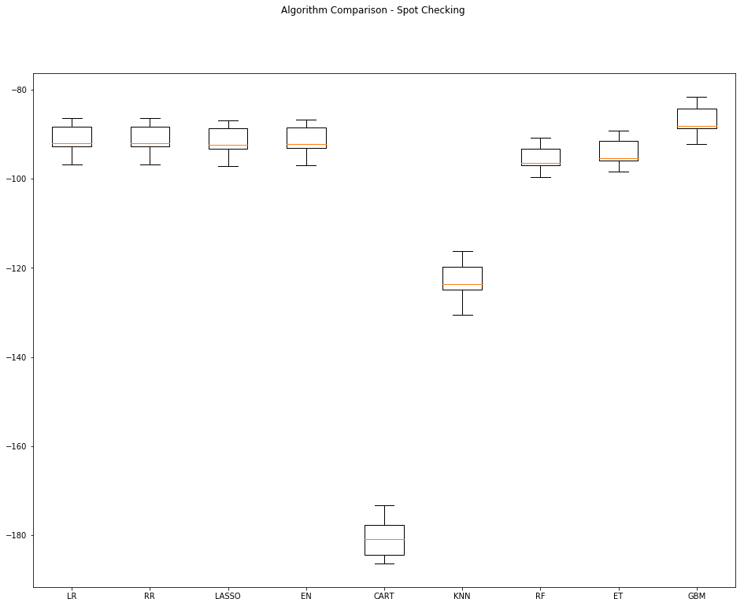

```python
fig = pyplot.figure()
fig.suptitle('Algorithm Comparison - Spot Checking')
ax = fig.add_subplot(111)
pyplot.boxplot(results)
ax.set_xticklabels(names)
pyplot.show()
```

## Section 5 - Improve Accuracy

After we achieve a short list of machine learning algorithms with good level of accuracy, we can leverage ways to improve the accuracy of the models.

### 5.a) Algorithm Tuning

```python
# Set up the comparison array
results = []
names = []
```

```python
# Tuning algorithm #1 - Ridge Regression
email_notify("Algorithm #1 tuning has begun! "+datetime.now().strftime('%a %B %d, %Y %I:%M:%S %p'))
startTimeModule = datetime.now()
paramGrid1 = dict(alpha=np.array([0.01,0.1,1,10,100]))
model1 = Ridge(random_state=seedNum)
kfold = KFold(n_splits=num_folds, random_state=seedNum)
grid1 = GridSearchCV(estimator=model1, param_grid=paramGrid1, scoring=scoring, cv=kfold)
grid_result1 = grid1.fit(x_train, y_train)

print("Best: %f using %s" % (grid_result1.best_score_, grid_result1.best_params_))
results.append(grid_result1.cv_results_['mean_test_score'])
names.append('RR')
means = grid_result1.cv_results_['mean_test_score']
stds = grid_result1.cv_results_['std_test_score']
params = grid_result1.cv_results_['params']
for mean, stdev, param in zip(means, stds, params):
    print("%f (%f) with: %r" % (mean, stdev, param))
print ('Model training time:',(datetime.now() - startTimeModule))
email_notify("Algorithm #1 tuning completed! "+datetime.now().strftime('%a %B %d, %Y %I:%M:%S %p'))
```

```
Best: -91.443420 using {'alpha': 100.0}
-91.443421 (3.349965) with: {'alpha': 0.01}
-91.443421 (3.349965) with: {'alpha': 0.1}
-91.443421 (3.349965) with: {'alpha': 1.0}
-91.443421 (3.349965) with: {'alpha': 10.0}
-91.443420 (3.349973) with: {'alpha': 100.0}
Model training time: 0:01:07.941336
```

```python
# Tuning algorithm #2 - Stochastic Gradient Boosting
email_notify("Algorithm #2 tuning has begun! "+datetime.now().strftime('%a %B %d, %Y %I:%M:%S %p'))
startTimeModule = datetime.now()
paramGrid2 = dict(n_estimators=np.array([200,300,400]))
model2 = GradientBoostingRegressor(random_state=seedNum)
kfold = KFold(n_splits=num_folds, random_state=seedNum)
grid2 = GridSearchCV(estimator=model2, param_grid=paramGrid2, scoring=scoring, cv=kfold)
grid_result2 = grid2.fit(x_train, y_train)

print("Best: %f using %s" % (grid_result2.best_score_, grid_result2.best_params_))
results.append(grid_result2.cv_results_['mean_test_score'])
names.append('GBM')
means = grid_result2.cv_results_['mean_test_score']
stds = grid_result2.cv_results_['std_test_score']
params = grid_result2.cv_results_['params']
for mean, stdev, param in zip(means, stds, params):
    print("%f (%f) with: %r" % (mean, stdev, param))
print ('Model training time:',(datetime.now() - startTimeModule))
email_notify("Algorithm #2 tuning completed! "+datetime.now().strftime('%a %B %d, %Y %I:%M:%S %p'))
```

```
Best: -82.283086 using {'n_estimators': 400}
-84.155482 (2.960091) with: {'n_estimators': 200}
-82.942068 (2.858616) with: {'n_estimators': 300}
-82.283086 (2.787591) with: {'n_estimators': 400}
Model training time: 20:34:58.787285
```

### 5.b) Compare Algorithms After Tuning

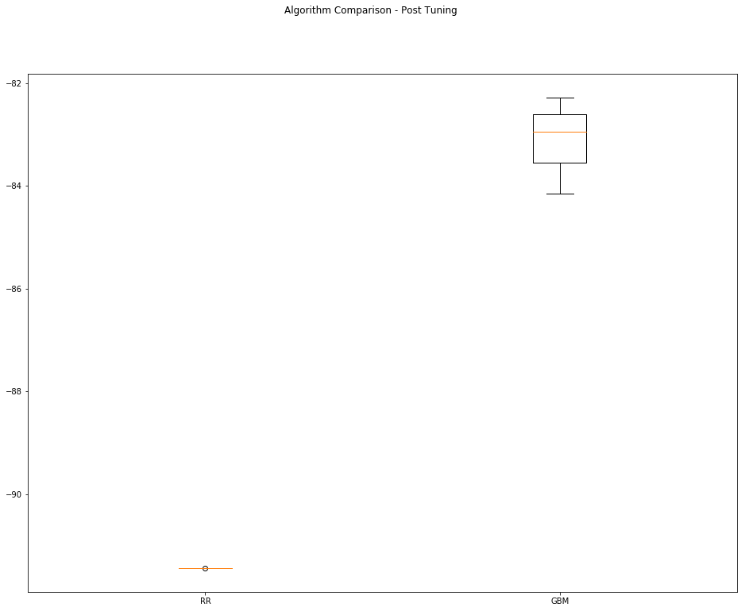

```python
fig = pyplot.figure()
fig.suptitle('Algorithm Comparison - Post Tuning')
ax = fig.add_subplot(111)
pyplot.boxplot(results)
ax.set_xticklabels(names)
pyplot.show()
```

## Section 6 - Finalize Model

Once we have narrow down to a model that we believe can make accurate predictions on unseen data, we are ready to finalize it. Finalizing a model may involve sub-tasks such as:

- Using an optimal model tuned to make predictions on unseen data.
- Creating a standalone model using the tuned parameters
- Saving an optimal model to file for later use.

```python
email_notify("Model Validation and Final Model Creation has begun! "+datetime.now().strftime('%a %B %d, %Y %I:%M:%S %p'))
```

### 6.a) Predictions on validation dataset

```python
model = GradientBoostingRegressor(n_estimators=400, random_state=seedNum)
model.fit(x_train, y_train)
predictions = model.predict(x_test)
print(mean_squared_error(y_test, predictions))
```

```
82.65072541456927
```

### 6.b) Create standalone model on entire training dataset

```python
startTimeModule = datetime.now()

# Combining the training and testing datasets to form the complete dataset that will be used for training the final model
x_complete = np.vstack((x_train, x_test))
y_complete = np.concatenate((y_train, y_test))
print("x_complete.shape: {} y_complete.shape: {}".format(x_complete.shape, y_complete.shape))

finalModel = GradientBoostingRegressor(n_estimators=400)
finalModel.fit(x_complete, y_complete)
print ('Model training time:',(datetime.now() - startTimeModule))
```

```
x_complete.shape: (515345, 90) y_complete.shape: (515345,)
Model training time: 0:51:41.151267
```

### 6.c) Save model for later use

```python
# modelName = 'finalModel_BinaryClass.sav'
# dump(finalModel, modelName)
```

```python
email_notify("Model Validation and Final Model Creation completed! "+datetime.now().strftime('%a %B %d, %Y %I:%M:%S %p'))
print ('Total time for the script:',(datetime.now() - startTimeScript))
```

```
Total time for the script: 1 day, 6:26:15.636824
```